# White Wine Quality Analysis by Orlando Neto

# Seção de Gráficos Univariados

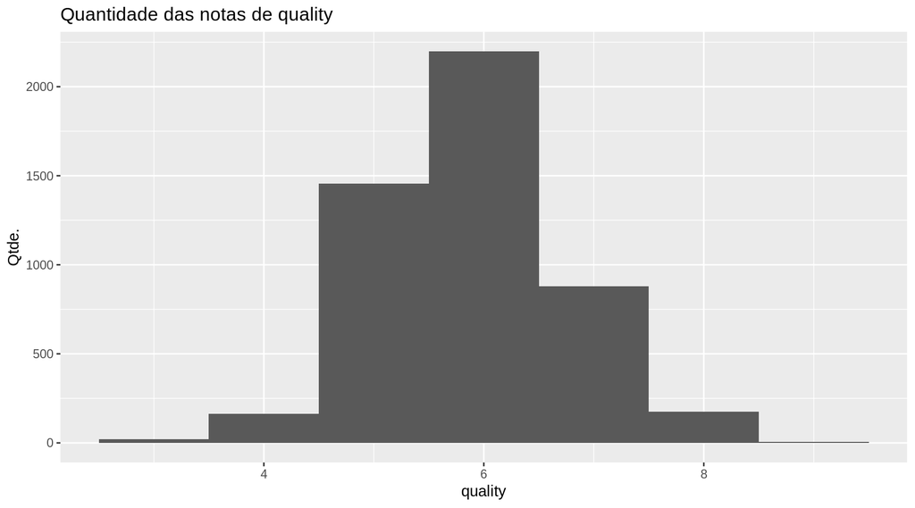

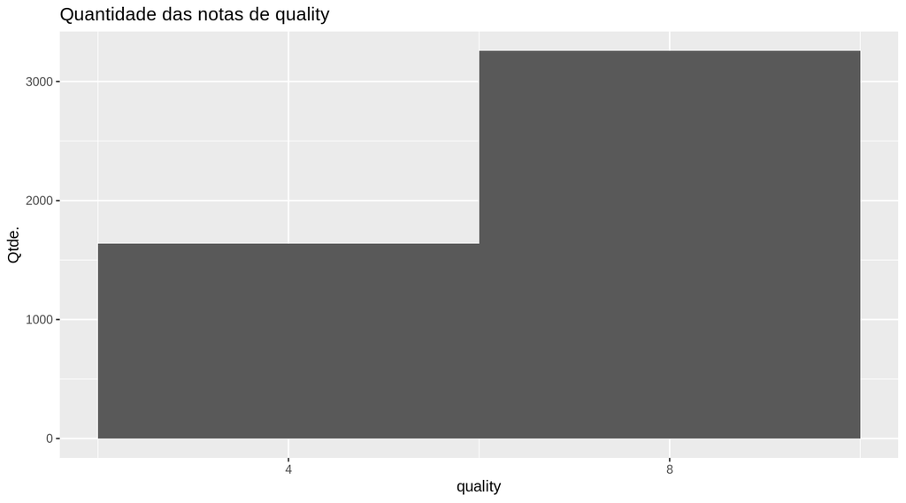

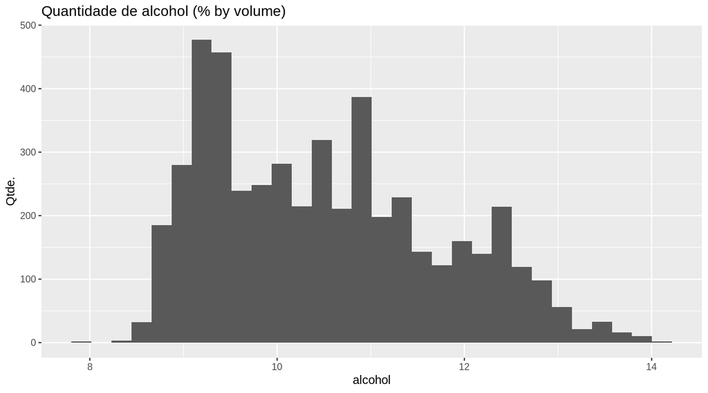

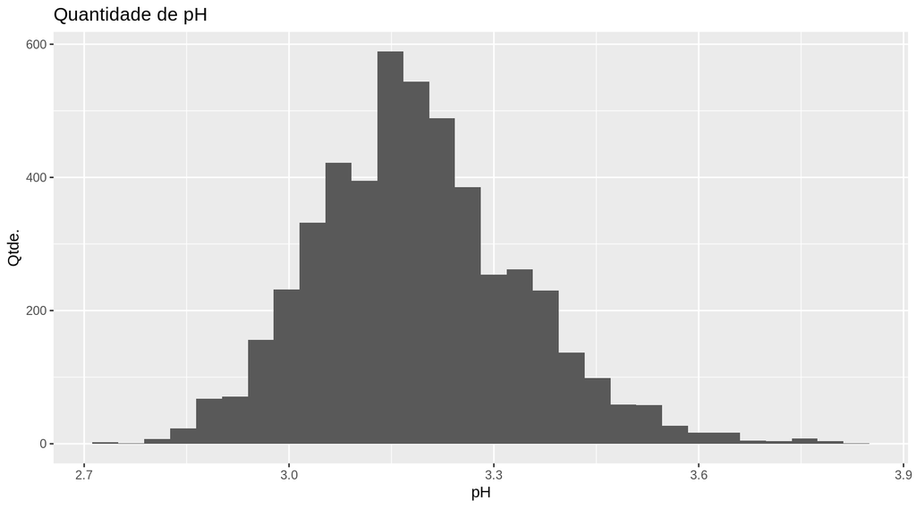

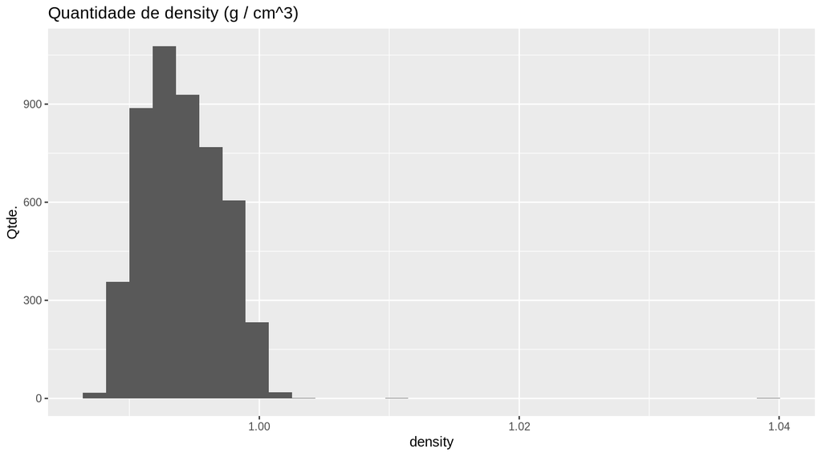

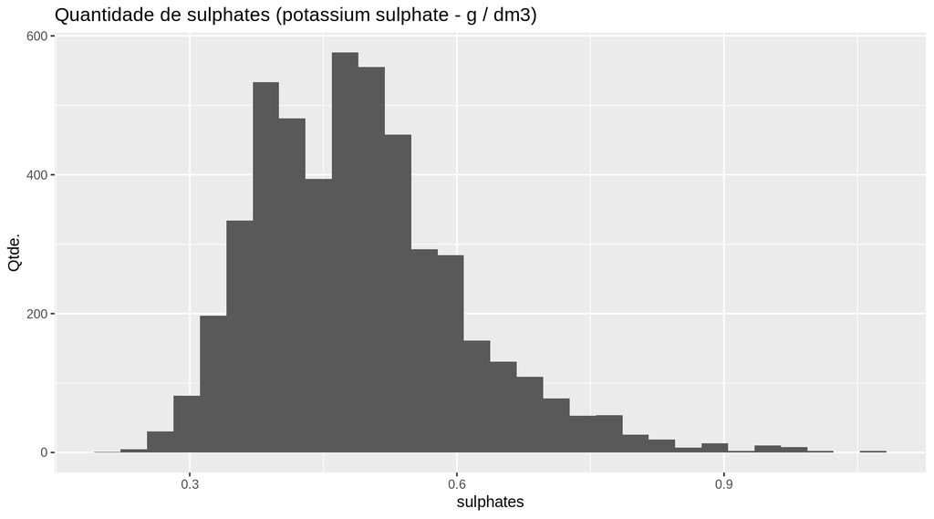

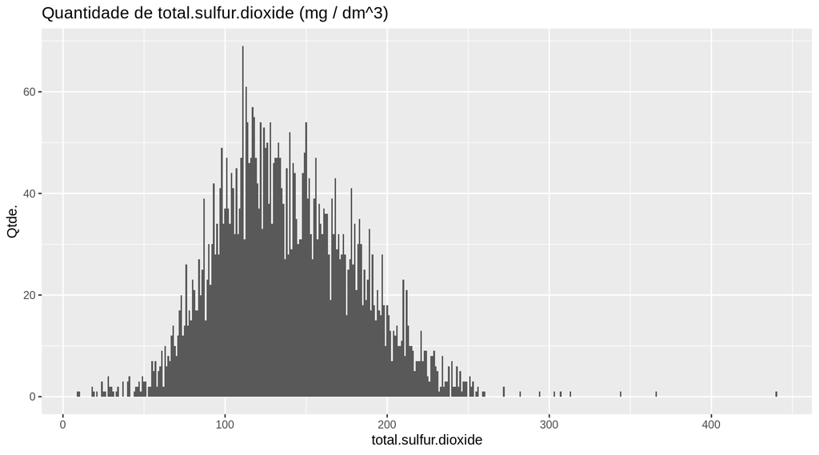

# Análise Univariada

### Qual é a estrutura do conjunto de dados?

> O conjunto de dados possui 4898 linhas e contém 13 atributos

### Quais são os principais atributos de interesse deste conjunto de dados?

> Os principais atributos do conjunto de dados são: quality, pH, fixed acidity, volatile acidity e citric acid

### Quais outros atributos você acha que podem lhe auxiliar na investigação destes atributos de interesse?

> Acredito que o atributo alcohol pode auxiliar na investigação

### Você criou novas variáveis a partir dos atributos existentes no conjunto de dados?

> Criei uma variável chamada sugar_categ que separa o teor de açucar residual entre menor que 1, onde segundo a documentação é baixo, até 45 que é considerado normal e maior que 45 que é considerado auto.

### Dos atributos investigados, distribuições incomuns foram encontradas? Você aplicou operações nos dados para limpá-los, ajustá-los ou mudar a forma dos dados? Se sim, por quê?

> Conforme a documentação do conjunto de dados diz, não existe valores missing nas colunas, então não foi preciso fazer um processo de ajuste nos dados.

# Seção de Gráficos Bivariados

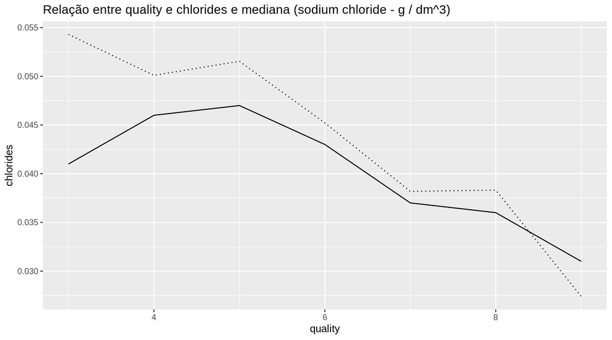

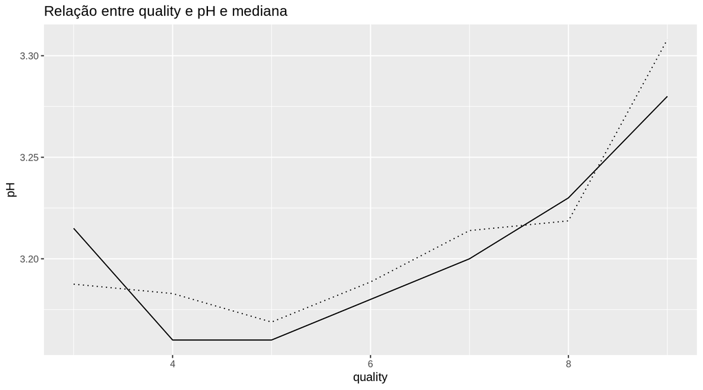

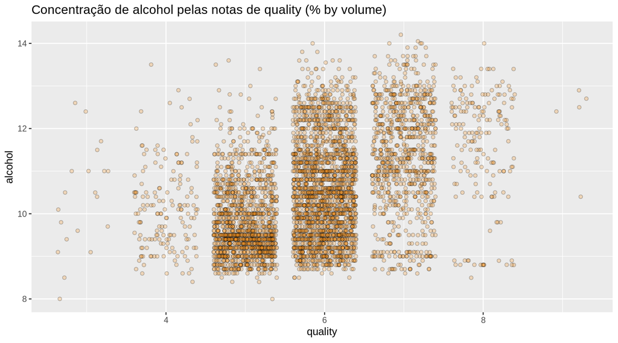

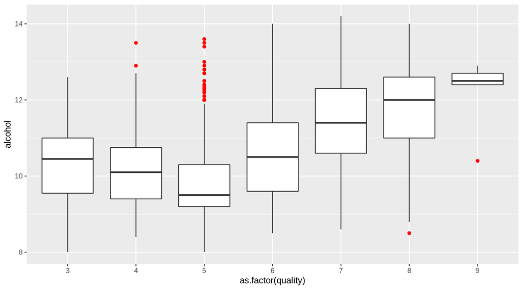

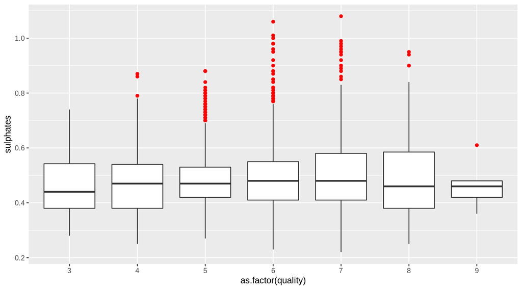

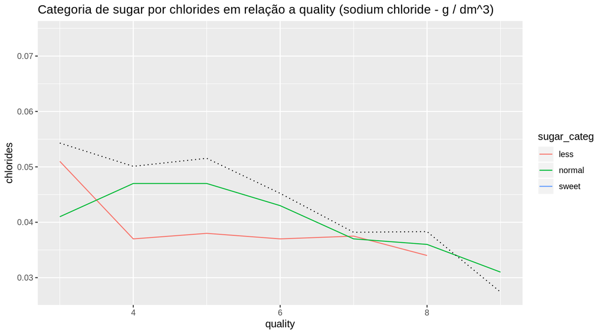

```
##
##  Pearson's product-moment correlation
##
## data:  data$quality and data$alcohol
## t = 33.858, df = 4896, p-value < 2.2e-16
## alternative hypothesis: true correlation is not equal to 0
## 95 percent confidence interval:
##  0.4126015 0.4579941
## sample estimates:
##       cor
## 0.4355747
```

```
##
##  Pearson's product-moment correlation
##
## data:  data$quality and data$pH
## t = 6.9917, df = 4896, p-value = 3.081e-12
## alternative hypothesis: true correlation is not equal to 0
## 95 percent confidence interval:
##  0.07162022 0.12707983
## sample estimates:
##        cor
## 0.09942725
```

```
##
##  Pearson's product-moment correlation
##
## data:  data$quality and data$density
## t = -22.581, df = 4896, p-value < 2.2e-16
## alternative hypothesis: true correlation is not equal to 0
## 95 percent confidence interval:
##  -0.3322718 -0.2815385
## sample estimates:
##        cor
## -0.3071233
```

```
##
##  Pearson's product-moment correlation
##
## data:  data$quality and data$total.sulfur.dioxide
## t = -12.418, df = 4896, p-value < 2.2e-16
## alternative hypothesis: true correlation is not equal to 0
## 95 percent confidence interval:
##  -0.2017563 -0.1474524
## sample estimates:
##        cor
## -0.1747372
```

```
##
##  Pearson's product-moment correlation
##
## data:  data$quality and data$residual.sugar
## t = -6.8603, df = 4896, p-value = 7.724e-12
## alternative hypothesis: true correlation is not equal to 0
## 95 percent confidence interval:
##  -0.12524103 -0.06976101
## sample estimates:
##         cor
## -0.09757683
```

```
##
##  Pearson's product-moment correlation
##
## data:  data$quality and data$citric.acid
## t = -0.6444, df = 4896, p-value = 0.5193
## alternative hypothesis: true correlation is not equal to 0
## 95 percent confidence interval:
##  -0.03720595  0.01880221
## sample estimates:
##          cor
## -0.009209091
```

> Nesses gráficos dá pra perceber uma relação entre chlorides e pH, pois quando o pH aumenta o chlorides diminui de acordo com a quality.

> Os gráficos acima demonstram que o teor alcolico do vinho influencia na qualidade, concentrando notas na unidade 6. No segundo gráfico o que é perceptivel são os outliers no teor alcolico da nota de número 5.

# Análise Bivariada

### Você observou algum relacionamento interessante entre os outros atributos (os que não são de interesse)?

> Ainda não observei nenhum atributo interessante entre os outros atributos.

### Qual foi o relacionamento mais forte encontrado?

> Segundo a correlação o relacionamento mais forte esta entre quality e density com um valor de correlação de -0.3071233 e alcohol com 0.4355747.

# Seção de Gráficos Multivariados

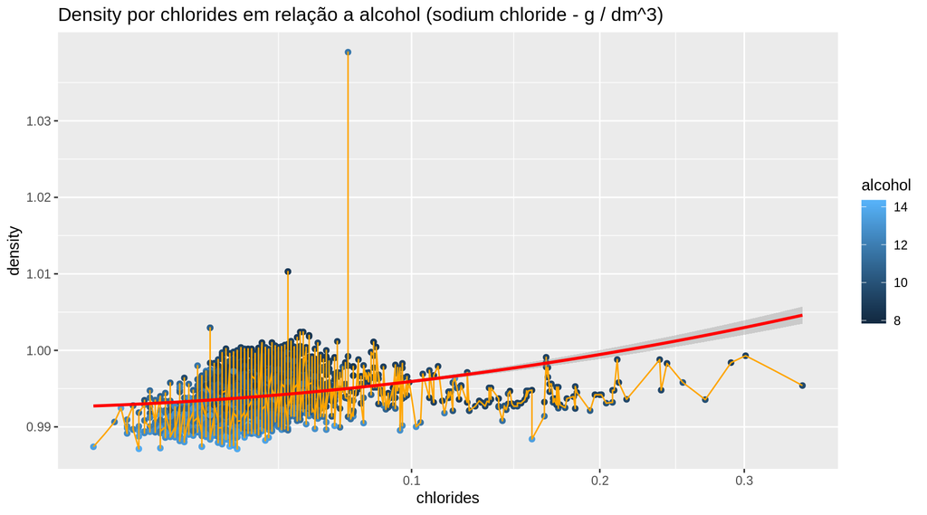

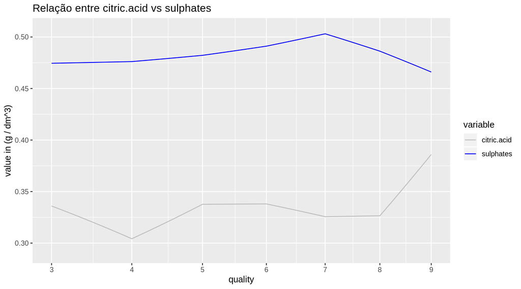

# Análise Multivariada

### Interações surpreendentes e/ou interessantes foram encontradas entre os atributos?

> Existe uma interação entre chlorides e density baseado na variável alcohol que pode ser entendida talvez utilizando um algoritmo de machine learning de regreção linear.

### OPCIONAL: Modelos foram criados usando este conjunto de dados? Discuta sobre os pontos fortes e as limitações do seu modelo.

# Gráficos Finais e Sumário

### Primeiro Gráfico

[figure not shown]

### Descrição do Primeiro Gráfico

> O primeiro gráfico mostra a relação entre a quality do vinho e a chlorides que é a porcentagem de sal no vinho. É perceptivel que quanto menos quantidade melhor é a qualidade do vinho.

### Segundo Gráfico

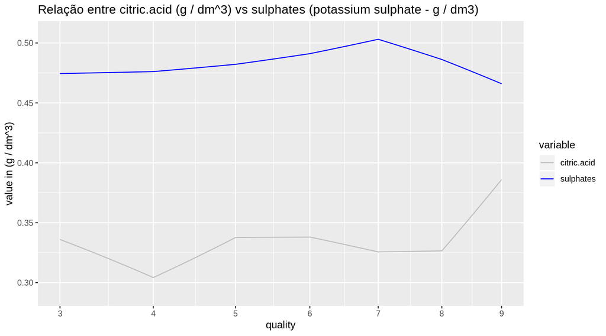

### Descrição do Segundo Gráfico

> Este segundo gráfico mostra a relação de citric.acid e sulphates todos eles relacionados à qualidade.

### Terceiro Gráfico

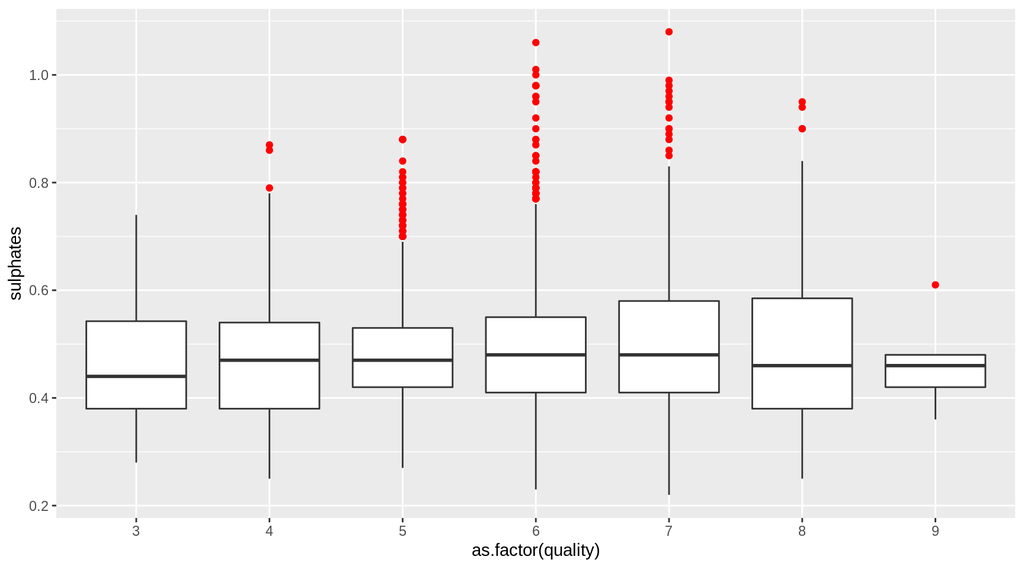

### Descrição do Terceiro Gráfico

> O terceiro gráfico mostra como na escala da nota quatro ate a nota 9 temos outliers na distribuição dos dados. Outro ponto a ser considerado é que temos uma mediana para quase todas as distribuições variando muito pouco.

# Reflexão

> A base de dados de vinhos é excelente, pois não foi necessário realizar um processo de pré-processamento dos dados para tratar N/A, junção entre variáveis entre outros. Analisei as variáveis separadamente para se ter uma idea de correlação entre as variáveis e observar comportamentos dos dados no conjunto. Identifiquei uma regressão linear nos dados o que pode talvez ser comprovado utilizando algum algoritmo de machine learning. O modelo é limitado e deveria conter mais registros e variáveis para se ter uma análise mais rica do comportamento dos dados. A maior dificuldade na análise foi descobrir quais variáveis seriam importantes para determinar o que realmente influência na qualidade de um vinho e como meus trabalhos até hoje só foram feitos em python tive um pouco de dificuldade na linguagem R principalmente em sua sintaxe. Como trabalho futuro, sugiro realizar um upgrade na base de dados e utilização de algum algoritmo de regressão linear com objetivo de fazer testes nas notas de qualidade e de acordo com a accuracy ele mesmo determinar a nota de qualidade de um novo vinho.